# Coliforms in The Panama Canal Watershed

Edward Habeck IV

11/30/2022

# **Introduction**

Coliforms are microorganisms commonly spread through feces, often known to contaminate sources of water. Abundance of such organisms are studied from water supplies around the world, as are the optimal conditions for them to thrive in laboratory settings. The data which I’m working with depicts samples of water from the Panama Canal Watershed, an essential component of its hydraulic function. Between seasons and from various locations, *E. coli* and total coliform counts were measured by most probable number (MPN) of bacteria per sample. Additionally, variables such as temperature, pH, and dissolved oxygen were included.

# **Analysis**

To begin, R’s memory is cleared and required packages are installed.

```
## here() starts at /home/ewhabe19/Biostatistics Fall 2022/Capstone-Project
```

#### Hypothesis #1: Abiotic variables will have influence upon one another. I want to later analyze how multiple variables impact coliform count, so it is important to first understand how non-coliform variables impact one another. For this, I’ll test how temperature affects dissolved O2 in samples collected from the Panama Canal Watershed.

Here, I’ll create a new dataset consisting of temperature and dissolve O2 data. I will test the relationship between temperature and dissolved oxygen of samples from the Panama Canal Watershed.

Histograms will be made for both individual variables for visualization and to look for outliers.

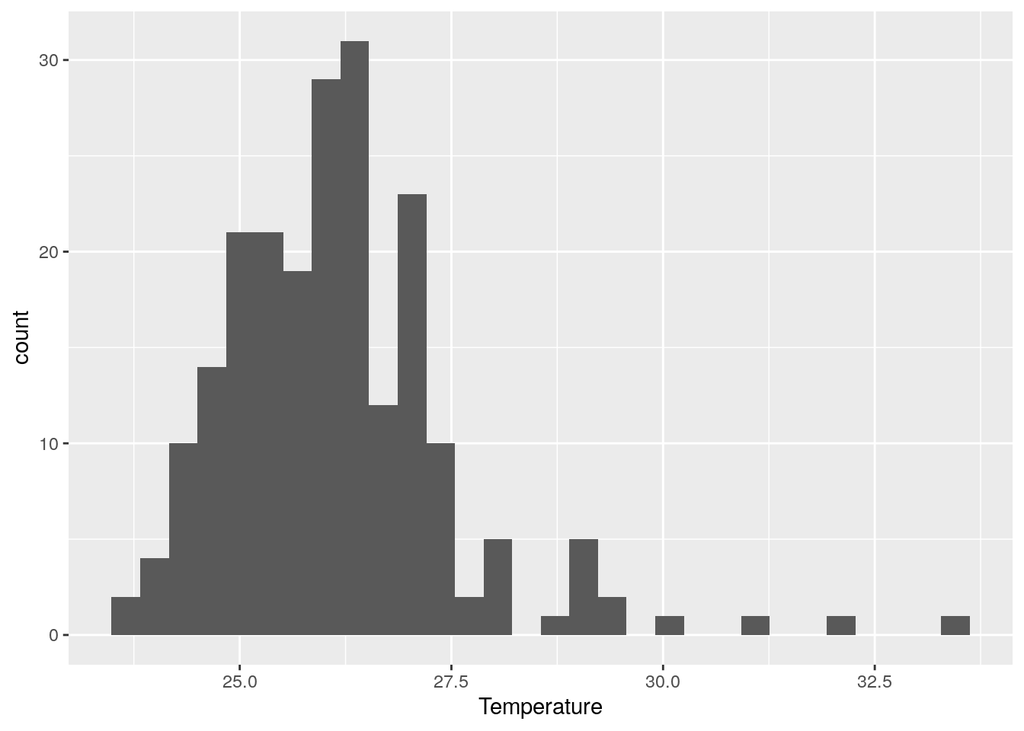

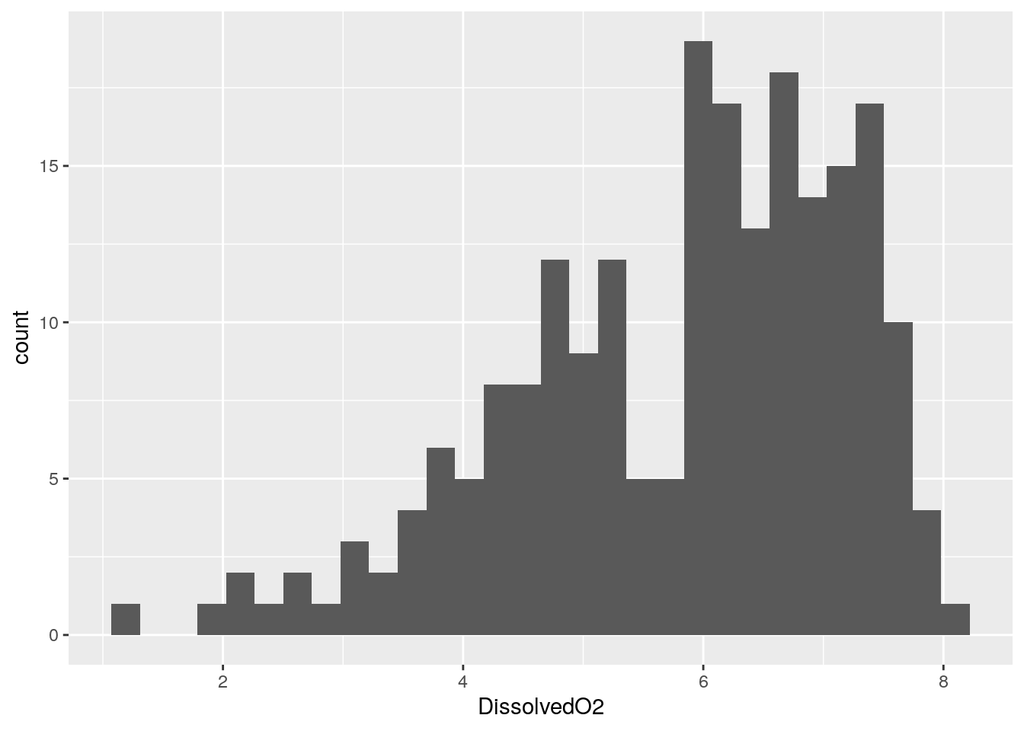

There does appear to be a large range of data between these histograms. I’m assuming that this will impact further testing, but I’ll see in autoplot.

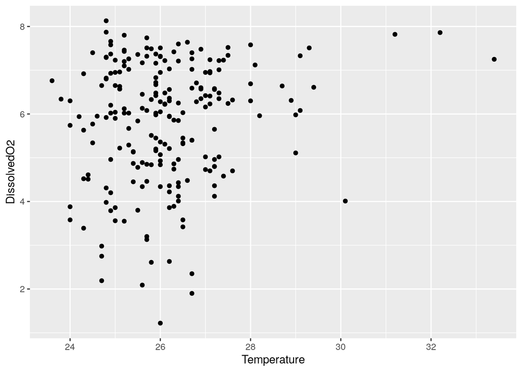

Though not in a perfect linear arrangement, I see a trend between points. I feel comfortable in calling this a weak positive due to their arrangement.

Autoplot will determine if this data is adequate for statistical testing, which is visualized in fitted values (which should be flat lines) and theoretical quartiles (ideally points following a linear trend).

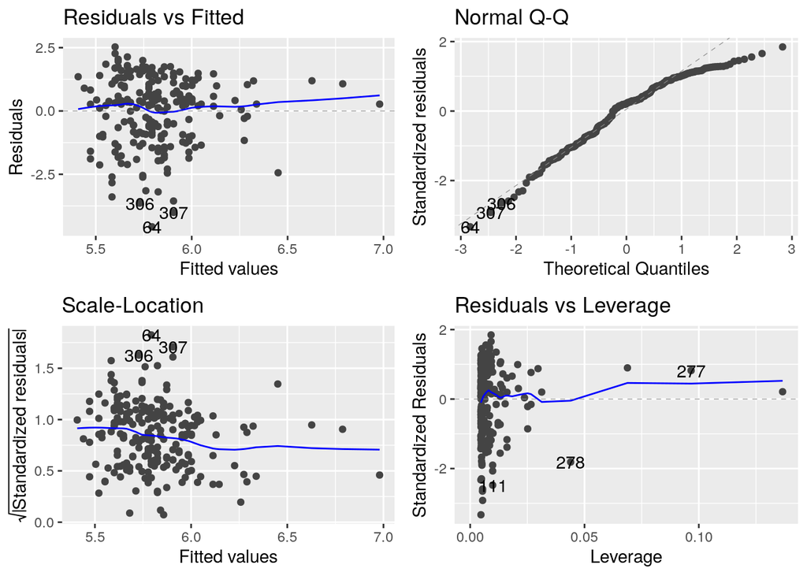

My fitted values are relatively flat with some deviation. Theoretical quartile points generally follow a linear trend, however, there is significant deviation towards its end. At the moment, a good model for working with oddly distributed data cannot be found, so standard testing with a linear model will be conducted.

Now, to analyze data through further statistical testing. As both temperature and dissolved O2 are continuous data, simple linear regression should be used.

```
##
## Call:
## lm(formula = DissolvedO2 ~ Temperature, data = Bacteria_Data1)
##
## Residuals:
##     Min      1Q  Median      3Q     Max
## -4.5731 -0.9432  0.2717  1.0690  2.5294
##
## Coefficients:
##             Estimate Std. Error t value Pr(>|t|)
## (Intercept)  1.62323    1.80274   0.900   0.3689
## Temperature  0.16038    0.06888   2.329   0.0208 *
## ---
## Signif. codes:  0 '***' 0.001 '**' 0.01 '*' 0.05 '.' 0.1 ' ' 1
##
## Residual standard error: 1.377 on 213 degrees of freedom
## Multiple R-squared:  0.02482,    Adjusted R-squared:  0.02024
## F-statistic: 5.422 on 1 and 213 DF,  p-value: 0.02082
```

This summary confirms that temperature is a significant predictor of dissolved O2 in samples from the Panama Canal Watershed, its p-value being 0.0208 (less that 0.05).

Finally, here is a depiction of the linear relationship between points when plotting Temperature against dissolved O2.

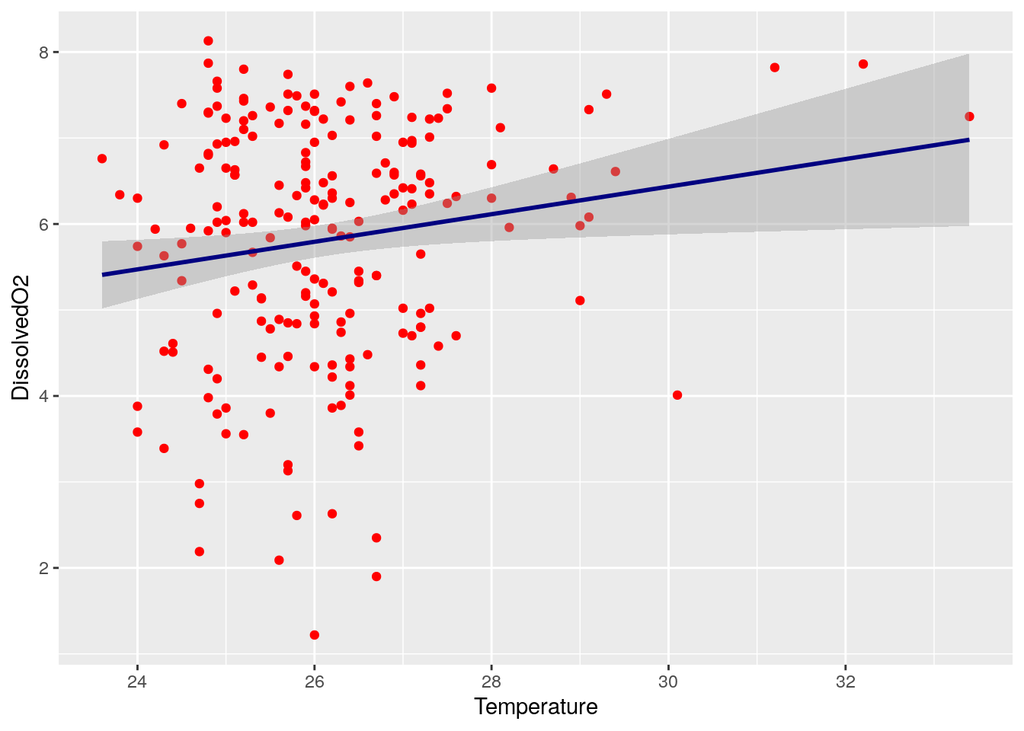

#### Hypothesis #2: I predict that abiotic factors such as pH will differ between sample sites. As locations where samples were gathered from are characterized by completely different features (e.g. pastures and forests), the composition of water and/or soil should differ significantly as well. I will test the relationship between pH and sample site along with the relationship between the pH of *all* sample sites.

Next, I’ll be determining the relationship between sample sites and their pH values.

I begin by selecting appropriate columns from the initial dataset and removing rows containing NA values. I will then create a histogram for pH, since this is a new variable in my analysis.

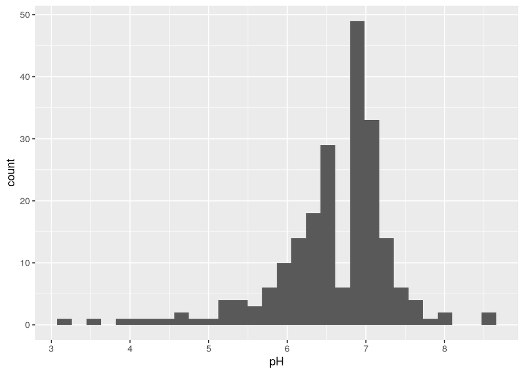

The range of data here is quite large. There is large group of points from approximately 6-7.5, but a long tail is present below 6. This could certainly impact how data is interpreted in tests.

Now to create a figure depicting pH by sample site. For this, I’ll use a box plot. As one form of data is categorical (sample site/Land_Use), this will depict the ranges of pH data which fall under each location.

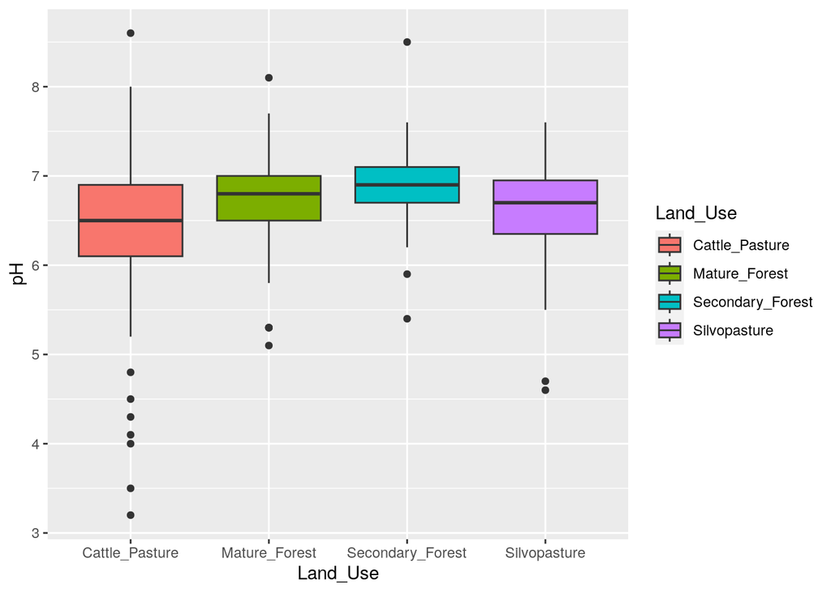